# Homework1: PCA of high-dimensional data

Data Science 1: Machine Learning Concepts - CEU 2021

Abduvosid Malikov

### Introduction

The purpose of this analysis is to perform PCA on the dataset. In the dataset, there are much more variables than observations: 40 observations of 1000 variables. The dataset has measurements of genes of tissues of healthy and diseased patients: the first 20 observations are coming from healthy and the others from diseased patients.

### Task A

Here, I load the data and perform PCA on this data with scaling features

### Task b

Visualize data points in the space of the first two principal components (look at the fviz_pca_ind function). What do you see in the figure?

You can see a plot that visualizes data points using principal components. We can see and we see two separate groups. Dot points in the plot labeled with the row names from the dataset. First group on the left has observations until (including) 20 (the healthy patients). Second group on the right shows observations from 21 to 40 (the diseased patients).

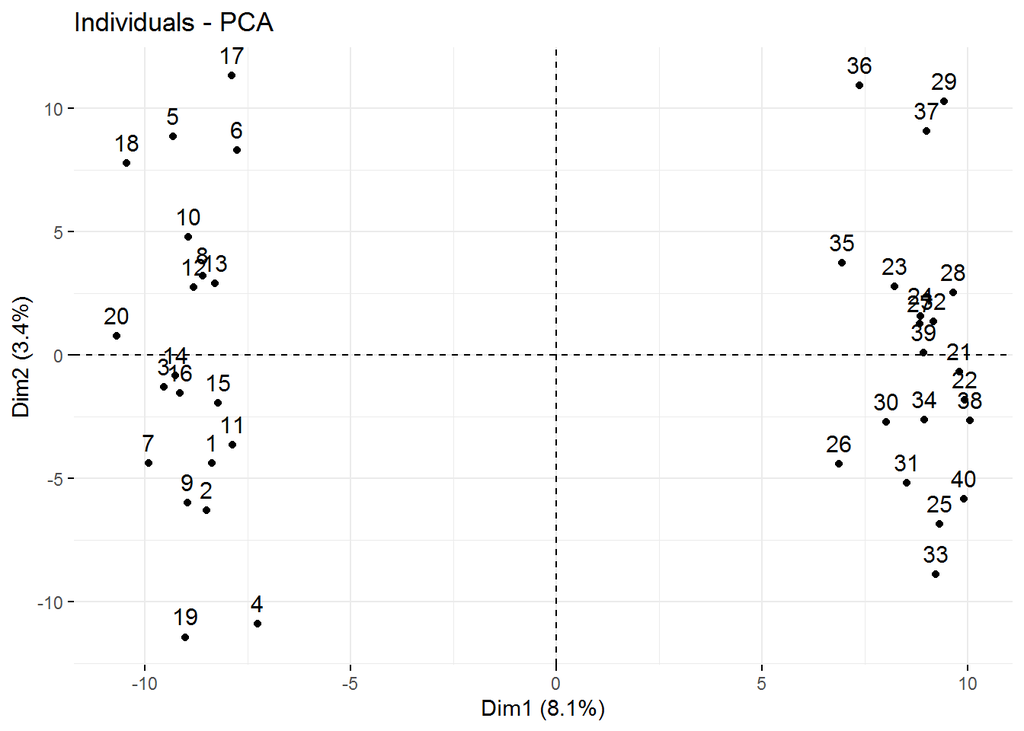

### Task c

Which individual features can matter the most in separating diseased from healthy?

The previous plot showed how the dataset was separated. Now I want to look at which features have high loadings for the first PC, that is, the largest coordinates.

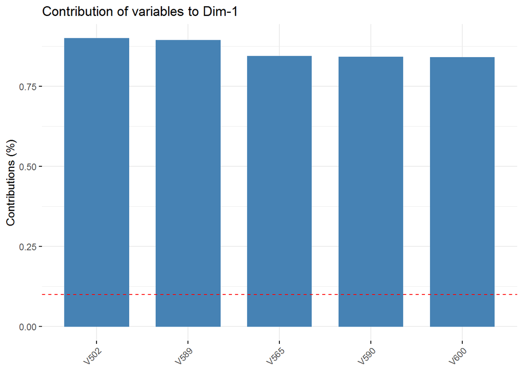

I take two features: V502 and V589. I plot the observations in the coordinate system defined by these two original features.

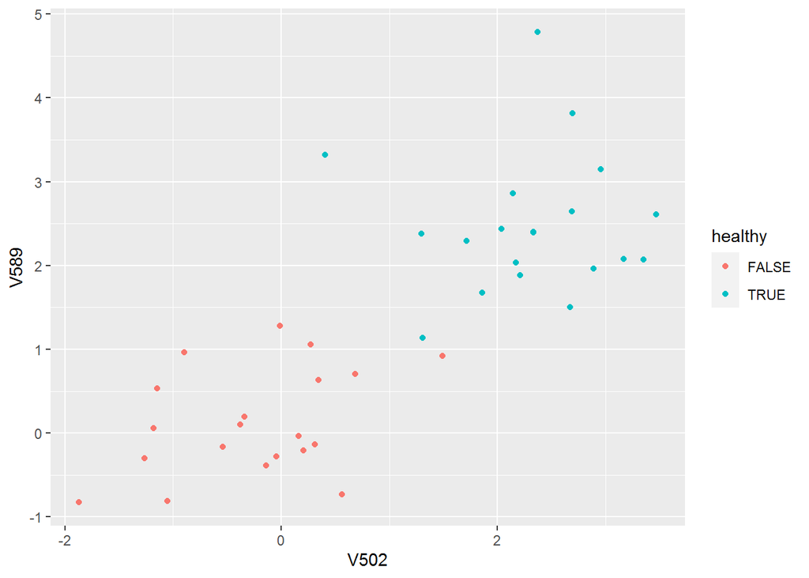

I can see two groups: healthy patients are the ones with high values from the both features. Diseased patients are the ones with the lowest value from the both features.